[figure not shown]

# CART Practice Assessment

```python
import pandas as pd
import numpy as np
import matplotlib.pyplot as plt
import seaborn as sns
import warnings
warnings.filterwarnings("ignore")
```

## Get the Data

```python
df = pd.read_csv('breast-cancer-wisconsin.csv')
```

```python
df.info()
```

```
<class 'pandas.core.frame.DataFrame'>
RangeIndex: 699 entries, 0 to 698
Data columns (total 11 columns):
Sample code number             699 non-null int64
Clump Thickness                699 non-null int64
Uniformity of Cell Size        699 non-null int64
Uniformity of Cell Shape       699 non-null int64
Marginal Adhesion              699 non-null int64
Single Epithelial Cell Size    699 non-null int64
Bare Nuclei                    699 non-null object
Bland Chromatin                699 non-null int64
Normal Nucleoli                699 non-null int64
Mitoses                        699 non-null int64
Class                          699 non-null int64
dtypes: int64(10), object(1)
memory usage: 60.2+ KB
```

**Get Summary Statistics**

Hint: Use Describe

```python
df.describe().T
```

|  | count | mean | std | min | 25% | 50% | 75% | max |
| --- | --- | --- | --- | --- | --- | --- | --- | --- |
| Sample code number | 699.0 | 1.071704e+06 | 617095.729819 | 61634.0 | 870688.5 | 1171710.0 | 1238298.0 | 13454352.0 |
| Clump Thickness | 699.0 | 4.417740e+00 | 2.815741 | 1.0 | 2.0 | 4.0 | 6.0 | 10.0 |
| Uniformity of Cell Size | 699.0 | 3.134478e+00 | 3.051459 | 1.0 | 1.0 | 1.0 | 5.0 | 10.0 |
| Uniformity of Cell Shape | 699.0 | 3.207439e+00 | 2.971913 | 1.0 | 1.0 | 1.0 | 5.0 | 10.0 |
| Marginal Adhesion | 699.0 | 2.806867e+00 | 2.855379 | 1.0 | 1.0 | 1.0 | 4.0 | 10.0 |
| Single Epithelial Cell Size | 699.0 | 3.216023e+00 | 2.214300 | 1.0 | 2.0 | 2.0 | 4.0 | 10.0 |
| Bland Chromatin | 699.0 | 3.437768e+00 | 2.438364 | 1.0 | 2.0 | 3.0 | 5.0 | 10.0 |
| Normal Nucleoli | 699.0 | 2.866953e+00 | 3.053634 | 1.0 | 1.0 | 1.0 | 4.0 | 10.0 |
| Mitoses | 699.0 | 1.589413e+00 | 1.715078 | 1.0 | 1.0 | 1.0 | 1.0 | 10.0 |
| Class | 699.0 | 3.447783e-01 | 0.475636 | 0.0 | 0.0 | 0.0 | 1.0 | 1.0 |

**Get the top five rows**

```python
df.head()
```

|  | Sample code number | Clump Thickness | Uniformity of Cell Size | Uniformity of Cell Shape | Marginal Adhesion | Single Epithelial Cell Size | Bare Nuclei | Bland Chromatin | Normal Nucleoli | Mitoses | Class |
| --- | --- | --- | --- | --- | --- | --- | --- | --- | --- | --- | --- |
| 0 | 1000025 | 5 | 1 | 1 | 1 | 2 | 1 | 3 | 1 | 1 | 0 |
| 1 | 1002945 | 5 | 4 | 4 | 5 | 7 | 10 | 3 | 2 | 1 | 0 |
| 2 | 1015425 | 3 | 1 | 1 | 1 | 2 | 2 | 3 | 1 | 1 | 0 |
| 3 | 1016277 | 6 | 8 | 8 | 1 | 3 | 4 | 3 | 7 | 1 | 0 |
| 4 | 1017023 | 4 | 1 | 1 | 3 | 2 | 1 | 3 | 1 | 1 | 0 |

## Data Cleaning

**Check Null Values**

```python
df.isnull().sum()
```

```
Sample code number             0
Clump Thickness                0
Uniformity of Cell Size        0
Uniformity of Cell Shape       0
Marginal Adhesion              0
Single Epithelial Cell Size    0
Bare Nuclei                    0
Bland Chromatin                0
Normal Nucleoli                0
Mitoses                        0
Class                          0
dtype: int64
```

**Check Data Types**

```python
df.get_dtype_counts()
```

```
int64     10
object     1
dtype: int64
```

**There is one object type, we need to check what it is and which feature it is in**

```python
df.dtypes[df.dtypes=='object']
```

```
Bare Nuclei    object
dtype: object
```

```python
df['Bare Nuclei'].value_counts()
```

```
1     402
10    132
5      30
2      30
3      28
8      21
4      19
?      16
9       9
7       8
6       4
Name: Bare Nuclei, dtype: int64
```

**There are 16 rows in Bare Nuclei which have the value '?'**

```python
df['Bare Nuclei']
```

```
0       1
1      10
2       2
3       4
4       1
       ..
694     2
695     1
696     3
697     4
698     5
Name: Bare Nuclei, Length: 699, dtype: object
```

```python
df[df['Bare Nuclei']!='?']['Bare Nuclei'].astype('int').median()
```

```
1.0
```

**Replace '?' with median value of Bare Nuclei**

```python
df.replace('?',1,inplace=True)
```

```python
df[df['Bare Nuclei']=='?']['Bare Nuclei']
```

```
Series([], Name: Bare Nuclei, dtype: object)
```

```python
df.get_dtype_counts()
```

```
int64     10
object     1
dtype: int64
```

**Convert the Object Data Type 'Bare Nuclei' to int64**

```python
df['Bare Nuclei']=df['Bare Nuclei'].astype('int64')
```

```python
df.get_dtype_counts()
```

```
int64    11
dtype: int64
```

## EDA

**Check Class Counts (0s and 1s) in Target Variable**

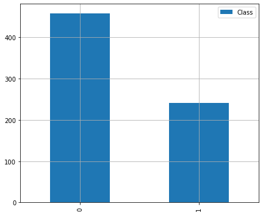

```python
plt.figure(figsize=(7,6))
df['Class'].value_counts().plot(kind='bar')
plt.legend()
plt.grid()
plt.show()
```

**Check the % of 0s and 1s in Target Variable Class**

```python
print("Percentage of 0's",round(df.Class.value_counts().values[0]/df.Class.count()*100,2),'%')
print("Percentage of 1's",round(df.Class.value_counts().values[1]/df.Class.count()*100,2),'%')
```

```
Percentage of 0's 65.52 %
Percentage of 1's 34.48 %
```

**Plot the distribution of each variable**

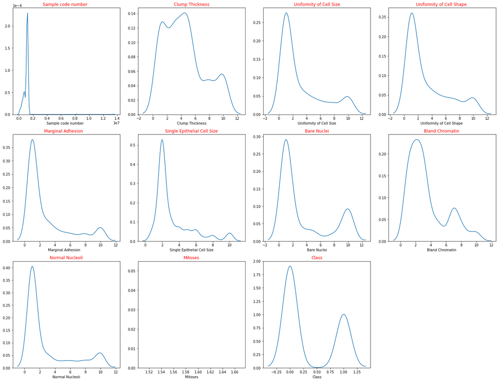

```python
data_plot=df
fig=plt.figure(figsize=(20,20))
for i in range(0,len(data_plot.columns)):
    ax=fig.add_subplot(4,4,i+1)
    sns.distplot(data_plot[data_plot.columns[i]],hist=False)
    ax.set_title(data_plot.columns[i],color='Red')
plt.tight_layout()
plt.show()
```

**Plot Correlation Map**

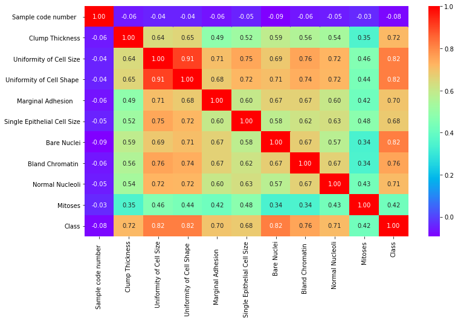

```python
plt.figure(figsize=(12,7))
sns.heatmap(df.corr(),annot=True,fmt='.2f',cmap='rainbow')
plt.show()
```

**Variables Uniformity of Cell Size, Uniformity of Cell Shape are highly positively correlated with each other (0.91)**

**Variables Uniformity of Cell Size, Uniformity of Cell Shape, Bare Nuclei are highly positively correlated with Target Variable 'Class'**

**Variable Mitosis has moderate positive correlation with Target Variable**

## Train Test Split

```python
from sklearn.model_selection import train_test_split
```

```python
X = df.drop(['Class','Sample code number  '],axis=1)
y = df['Class']
X_train, X_test, y_train, y_test = train_test_split(X, y, test_size=0.30, random_state=101)
```

## Training a Decision Tree Model

```python
from sklearn.tree import DecisionTreeClassifier
```

**Create an instance of DecisionTreeClassifier() called dtree and fit it to the training data.**

```python
dtree = DecisionTreeClassifier(random_state=123)
```

```python
dtree.fit(X_train,y_train)
```

```
DecisionTreeClassifier(random_state=123)
```

## Predictions and Evaluation of Decision Tree

```python
predictions = dtree.predict(X_test)
```

**Print Feature Importances**

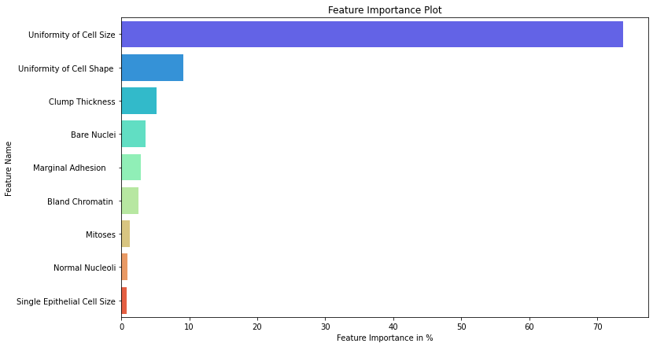

```python
x=pd.DataFrame(dtree.feature_importances_*100,index=X_train.columns).sort_values(by=0,ascending=False)
plt.figure(figsize=(12,7))
sns.barplot(x[0],x.index,palette='rainbow')
plt.ylabel('Feature Name')
plt.xlabel('Feature Importance in %')
plt.title('Feature Importance Plot')
plt.show()
```

```python
from sklearn.metrics import classification_report,confusion_matrix,accuracy_score,roc_auc_score,roc_curve
```

**Print Classification Report**

```python
print(classification_report(y_test,predictions))
```

```
              precision    recall  f1-score   support

           0       0.93      0.95      0.94       129
           1       0.92      0.89      0.91        81

    accuracy                           0.93       210
   macro avg       0.93      0.92      0.92       210
weighted avg       0.93      0.93      0.93       210
```

**Print Confusion Matrix**

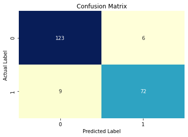

```python
sns.heatmap(confusion_matrix(y_test,predictions),annot=True, fmt='d', cbar=False,cmap='YlGnBu')
plt.xlabel('Predicted Label')
plt.ylabel('Actual Label')
plt.title('Confusion Matrix')
plt.show()
```

**Print Accuracy Score**

```python
print('Accuracy Score is',round(accuracy_score(y_test, predictions),2)*100,'%')
```

```
Accuracy Score is 93.0 %
```

**Print the Area Under the Curve**

```python
print('Area Under the Curve is',round(roc_auc_score(y_test,dtree.predict_proba(X_test)[:,1]),2)*100,'%')
```

```
Area Under the Curve is 92.0 %
```

**Plot ROC_Curve**

```python
dt_fpr, dt_tpr,_=roc_curve(y_test,dtree.predict_proba(X_test)[:,1])
```

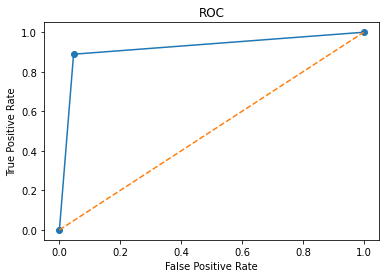

```python
plt.plot(dt_fpr,dt_tpr, marker='o', label='Decision Tree')
plt.plot([0, 1], [0, 1], linestyle='--')
plt.xlabel('False Positive Rate')
plt.ylabel('True Positive Rate')
plt.title('ROC')
plt.show()
```

## Conclusion

Uniformity of cell size plays an important part in deciding whether the Tumor is benign or malignant (Highest feature importance)

Cases where the Tumor is Actually Malignant , there are 9 instances where model predicted the Tumor to be Benign

Cases where the Tumor is Actually Benign but model predicted them to be Malignant are 6

The Area Under the Curve is 92%

Accuracy score on Testing set is 93%